# Notebook

## Cryptocurrency Price Movement Prediction Using Time-Series Machine Learning

### 1. Introduction

[figure not shown]

Cryptocurrency markets are known for their high volatility and limited informational efficiency. Prior research has shown that Bitcoin, for example, exhibits persistent inefficiencies and irregular price dynamics, making it difficult for past information to reliably predict future movements (Urquhart, 2016). These characteristics raise an important question: despite the noise and instability, do short-term price patterns contain any meaningful predictive signals?

To explore this, the present project analyzes daily historical data and examines whether recent price behavior can predict short-term direction across a diverse set of major cryptocurrencies. The goal is not to forecast exact prices, but rather to evaluate whether machine learning models can classify next-day (and multi-day) price direction using engineered autoregressive features.

By focusing on 12 widely traded non-stablecoins including Bitcoin, Ethereum, Binance Coin, Cardano, Solana, XRP, and others. The analysis provides a broad view of how predictable short-term crypto movement actually is. Stablecoins are excluded because their prices are intentionally pegged and lack meaningful volatility, which would distort the classification task.

### 2. Data

#### 2.1 Data Overview

The dataset comes from the *Cryptocurrency Historical Prices* collection on Kaggle, which provides daily open, close, high, low, and volume data for many cryptocurrencies.

For this project, I use 12 major cryptocurrencies: Bitcoin (BTC), Ethereum (ETH), Binance Coin (BNB), XRP, Litecoin (LTC), Cardano (ADA), Polkadot (DOT), Solana (SOL), Uniswap (UNI), ChainLink (LINK), Dogecoin (DOGE), and Monero (XMR). Each is stored in a separate CSV file. The files are loaded, labeled by coin type, combined into one dataset, and sorted by date to prepare for autoregressive feature engineering.

Stablecoins (e.g., USDT, USDC, Tether, Wrapped Bitcoin, etc.) are excluded because their prices are pegged to fiat currencies and do not reflect true market-driven price dynamics. Including them would artificially lower volatility and obscure the predictive modeling of real crypto price movements.

```python
# 1. Environment and Libraries
import pandas as pd
import numpy as np
import matplotlib.pyplot as plt
from sklearn.model_selection import train_test_split, TimeSeriesSplit
from sklearn.ensemble import RandomForestClassifier
from sklearn.metrics import accuracy_score, confusion_matrix, classification_report, roc_curve, auc

# Load selected pure cryptocurrency files (exclude stablecoins)
coin_files = [
    ("coin_Bitcoin.csv", "BTC"),
    ("coin_Ethereum.csv", "ETH"),
    ("coin_BinanceCoin.csv", "BNB"),
    ("coin_XRP.csv", "XRP"),
    ("coin_Litecoin.csv", "LTC"),
    ("coin_Cardano.csv", "ADA"),
    ("coin_Polkadot.csv", "DOT"),
    ("coin_Solana.csv", "SOL"),
    ("coin_Uniswap.csv", "UNI"),
    ("coin_ChainLink.csv", "LINK"),
    ("coin_Dogecoin.csv", "DOGE"),
    ("coin_Monero.csv", "XMR"),
]

dfs = []
for file, label in coin_files:
    df_coin = pd.read_csv(file)
    df_coin["coin"] = label
    dfs.append(df_coin)
df = pd.concat(dfs, ignore_index=True)

df["Date"] = pd.to_datetime(df["Date"])
df = df.sort_values(["coin", "Date"])

print("Dataset Summary Statistics:")
display(df.describe())

print("First 5 Rows of Dataset:")
display(df.head())
```

```
Dataset Summary Statistics:
```

|  | SNo | Date | High | Low | Open | Close | Volume | Marketcap |
| --- | --- | --- | --- | --- | --- | --- | --- | --- |
| count | 21662.000000 | 21662 | 21662.000000 | 21662.000000 | 21662.000000 | 21662.000000 | 2.166200e+04 | 2.166200e+04 |
| mean | 1191.356061 | 2018-04-03 15:26:19.463484416 | 1012.777107 | 951.326844 | 983.632999 | 985.305427 | 2.820808e+09 | 2.448957e+10 |
| min | 1.000000 | 2013-04-29 23:59:59 | 0.000089 | 0.000085 | 0.000087 | 0.000087 | 0.000000e+00 | 0.000000e+00 |
| 25% | 484.000000 | 2016-07-02 23:59:59 | 0.219080 | 0.200827 | 0.208113 | 0.209434 | 3.942396e+06 | 2.231196e+08 |
| 50% | 1086.000000 | 2018-07-17 23:59:59 | 5.234680 | 4.684970 | 4.910135 | 4.971710 | 8.546236e+07 | 1.837776e+09 |
| 75% | 1831.000000 | 2020-03-10 23:59:59 | 123.727298 | 115.633575 | 119.496053 | 119.594012 | 1.267220e+09 | 1.061993e+10 |
| max | 2991.000000 | 2021-07-06 23:59:59 | 64863.098908 | 62208.964366 | 63523.754869 | 63503.457930 | 3.509679e+11 | 1.186364e+12 |
| std | 810.491852 | NaN | 4930.145612 | 4610.791357 | 4782.662320 | 4787.790136 | 8.923269e+09 | 9.115818e+10 |

```
First 5 Rows of Dataset:
```

|  | SNo | Name | Symbol | Date | High | Low | Open | Close | Volume | Marketcap | coin |
| --- | --- | --- | --- | --- | --- | --- | --- | --- | --- | --- | --- |
| 12477 | 1 | Cardano | ADA | 2017-10-02 23:59:59 | 0.030088 | 0.019969 | 0.024607 | 0.025932 | 57641300.0 | 6.288991e+08 | ADA |
| 12478 | 2 | Cardano | ADA | 2017-10-03 23:59:59 | 0.027425 | 0.020690 | 0.025757 | 0.020816 | 16997800.0 | 5.396927e+08 | ADA |
| 12479 | 3 | Cardano | ADA | 2017-10-04 23:59:59 | 0.022806 | 0.020864 | 0.020864 | 0.021931 | 9000050.0 | 5.686195e+08 | ADA |
| 12480 | 4 | Cardano | ADA | 2017-10-05 23:59:59 | 0.022154 | 0.020859 | 0.021951 | 0.021489 | 5562510.0 | 5.571390e+08 | ADA |
| 12481 | 5 | Cardano | ADA | 2017-10-06 23:59:59 | 0.021542 | 0.018360 | 0.021359 | 0.018539 | 7780710.0 | 4.806646e+08 | ADA |

#### 2.2 Feature Engineering:

To enable effective machine learning on cryptocurrency price data, a variety of features are engineered to capture different aspects of market behavior. The full set of features includes:

- **Date**: The date of each observation (used for time alignment, not as a predictor).
- **Close**: The closing price (used for target construction and reference, not as a predictor).
- **Volume**: Daily trading volume, reflecting market activity.
- **Marketcap**: Total market capitalization, indicating the overall value of the cryptocurrency.
- **Lag Features**: Previous closing prices (e.g., lag_1, lag_7) to capture short-term memory and trends.
- **Returns and Momentum**: *n-day return* (e.g., ret_3, ret_7) is the simple return over a fixed window $$ \mathrm{ret}_n = \frac{\mathrm{Close}_t - \mathrm{Close}_{t-n}}{\mathrm{Close}_{t-n}} $$
- **Moving Averages**: Simple moving average (SMA) $$ \mathrm{ma}_n(t) = \frac{1}{n} \sum_{i=0}^{n-1} \mathrm{Close}_{t-i} $$
- **Volatility**: Rolling standard deviation of returns (volatility): $$ \mathrm{volatility}_n(t) = \mathrm{std}(\mathrm{return}_{t-n+1}, \ldots, \mathrm{return}_t) $$
- **Volume Change**: Change of daily trading volume $$ \mathrm{volume\_change}_t = \frac{\mathrm{Volume}_t - \mathrm{Volume}_{t-1}}{\mathrm{Volume}_{t-1}} $$
- **Streaks**: Consecutive up/down days (up_streak, down_streak) to capture persistent trends or reversals. (See code for implementation.)
- **Rolling Max/Min and Quantiles**:
  - Rolling max: $$ \mathrm{max}_n(t) = \max(\mathrm{Close}_{t-n+1}, \ldots, \mathrm{Close}_t) $$
  - Rolling min: $$ \mathrm{min}_n(t) = \min(\mathrm{Close}_{t-n+1}, \ldots, \mathrm{Close}_t) $$
  - Rolling quantile (e.g., 90th percentile): $$ \mathrm{q90\_30}(t) = \text{90th percentile of } \{\mathrm{Close}_{t-29}, \ldots, \mathrm{Close}_t\} $$
- **Multi-horizon Targets**: Binary targets for 1, 3, 5, and 7-day price direction, enabling multi-horizon prediction. These engineered features provide the foundation for all subsequent modeling, allowing the algorithms to learn from both recent and historical market patterns.

```python
# Create time-series features for modeling
feature_df = df.copy()
feature_df = feature_df.sort_values(['coin', 'Date'])

# Lag features (keep lag_1 and lag_7 to reduce multicollinearity)
feature_df['lag_1'] = feature_df.groupby('coin')['Close'].shift(1)
feature_df['lag_7'] = feature_df.groupby('coin')['Close'].shift(7)

# Daily return (percentage)
feature_df['return'] = feature_df.groupby('coin')['Close'].pct_change()

# 3-day and 7-day returns
feature_df['ret_3'] = feature_df.groupby('coin')['Close'].pct_change(3)
feature_df['ret_7'] = feature_df.groupby('coin')['Close'].pct_change(7)

# Moving averages (7-day and 30-day)
feature_df['ma_7'] = feature_df.groupby('coin')['Close'].transform(lambda x: x.rolling(window=7).mean())
feature_df['ma_30'] = feature_df.groupby('coin')['Close'].transform(lambda x: x.rolling(window=30).mean())

# Exponential moving averages (EMA)
feature_df['ema_7'] = feature_df.groupby('coin')['Close'].transform(lambda x: x.ewm(span=7, adjust=False).mean())
feature_df['ema_30'] = feature_df.groupby('coin')['Close'].transform(lambda x: x.ewm(span=30, adjust=False).mean())

# Rolling volatility (30-day std of returns)
feature_df['volatility'] = feature_df.groupby('coin')['return'].transform(lambda x: x.rolling(window=30).std())

# Volume change relative to previous day (percentage)
feature_df['volume_change'] = feature_df.groupby('coin')['Volume'].pct_change()

# Consecutive up/down days
feature_df['up_streak'] = feature_df.groupby('coin')['return'].transform(lambda x: (x > 0).astype(int).groupby((x <= 0).cumsum()).cumcount())
feature_df['down_streak'] = feature_df.groupby('coin')['return'].transform(lambda x: (x < 0).astype(int).groupby((x >= 0).cumsum()).cumcount())

# 7-day max/min close
feature_df['max_7'] = feature_df.groupby('coin')['Close'].transform(lambda x: x.rolling(window=7).max())
feature_df['min_7'] = feature_df.groupby('coin')['Close'].transform(lambda x: x.rolling(window=7).min())

# 14-day cumulative return
feature_df['momentum_14'] = feature_df.groupby('coin')['Close'].transform(lambda x: x.pct_change(periods=14))

# 30-day 90th percentile of close
feature_df['q90_30'] = feature_df.groupby('coin')['Close'].transform(lambda x: x.rolling(window=30).quantile(0.9))

# Remove coin column
feature_df = feature_df.drop(columns=['coin'])

# Drop rows with any NaN values (from rolling/lags/target)
feature_df = feature_df.dropna().reset_index(drop=True)

# Remove original columns not needed for modeling
remove_cols = [col for col in feature_df.columns if col.lower() in ['sno','name','open','high','low','symbol']]
feature_df = feature_df.drop(columns=remove_cols)

# Dynamically select all feature columns except Date, Close, and targets
feature_columns = [col for col in feature_df.columns if col not in ['Date', 'Close', 'target', 'target_1', 'target_3', 'target_5', 'target_7']]

# Only keep feature columns
feature_df = feature_df[['Date','Close'] + feature_columns]

# Clean infinite values if any
feature_df = feature_df.replace([np.inf, -np.inf], np.nan).dropna().reset_index(drop=True)

# Show all feature columns
print("All Features in Dataset:")
for col in feature_df.columns:
    print(col)
display(feature_df.head())
```

```
All Features in Dataset:
Date
Close
Volume
Marketcap
lag_1
lag_7
return
ret_3
ret_7
ma_7
ma_30
ema_7
ema_30
volatility
volume_change
up_streak
down_streak
max_7
min_7
momentum_14
q90_30
```

|  | Date | Close | Volume | Marketcap | lag_1 | lag_7 | return | ret_3 | ret_7 | ma_7 | ... | ema_7 | ema_30 | volatility | volume_change | up_streak | down_streak | max_7 | min_7 | momentum_14 | q90_30 |
| --- | --- | --- | --- | --- | --- | --- | --- | --- | --- | --- | --- | --- | --- | --- | --- | --- | --- | --- | --- | --- | --- |
| 0 | 2017-11-01 23:59:59 | 0.022986 | 9382780.0 | 5.959648e+08 | 0.030437 | 0.027527 | -0.244807 | -0.196481 | -0.164973 | 0.027142 | ... | 0.026972 | 0.026723 | 0.104732 | 0.284529 | 0 | 1 | 0.030437 | 0.022986 | -0.138794 | 0.030457 |
| 1 | 2017-11-02 23:59:59 | 0.021306 | 6165050.0 | 5.523996e+08 | 0.022986 | 0.027132 | -0.073100 | -0.254593 | -0.214726 | 0.026310 | ... | 0.025556 | 0.026374 | 0.098904 | -0.342940 | 0 | 2 | 0.030437 | 0.021306 | -0.211824 | 0.030457 |
| 2 | 2017-11-03 23:59:59 | 0.022628 | 2836080.0 | 5.866803e+08 | 0.021306 | 0.026382 | 0.062058 | -0.256572 | -0.142284 | 0.025773 | ... | 0.024824 | 0.026132 | 0.099058 | -0.539975 | 1 | 0 | 0.030437 | 0.021306 | -0.261239 | 0.030457 |
| 3 | 2017-11-04 23:59:59 | 0.022022 | 2626920.0 | 5.709685e+08 | 0.022628 | 0.025866 | -0.026781 | -0.041943 | -0.148612 | 0.025224 | ... | 0.024123 | 0.025867 | 0.099125 | -0.073750 | 0 | 1 | 0.030437 | 0.021306 | -0.225561 | 0.030457 |
| 4 | 2017-11-05 23:59:59 | 0.020635 | 2396230.0 | 5.350051e+08 | 0.022022 | 0.028607 | -0.062987 | -0.031489 | -0.278671 | 0.024085 | ... | 0.023251 | 0.025529 | 0.096324 | -0.087818 | 0 | 2 | 0.030437 | 0.020635 | -0.255828 | 0.030457 |

5 rows × 21 columns

```python
# Multi-horizon target engineering
horizons = [1, 3, 5, 7]
for h in horizons:
    feature_df[f'target_{h}'] = (feature_df['Close'].shift(-h) > feature_df['Close']).astype(int)

# Remove the last max(horizons) rows to avoid lookahead bias
feature_df = feature_df.iloc[:-max(horizons)].reset_index(drop=True)

# Drop any remaining NaN values
feature_df = feature_df.dropna().reset_index(drop=True)

# Show new features and targets
print('Features:', feature_df.columns.tolist())
display(feature_df.head())
```

```
Features: ['Date', 'Close', 'Volume', 'Marketcap', 'lag_1', 'lag_7', 'return', 'ret_3', 'ret_7', 'ma_7', 'ma_30', 'ema_7', 'ema_30', 'volatility', 'volume_change', 'up_streak', 'down_streak', 'max_7', 'min_7', 'momentum_14', 'q90_30', 'target_1', 'target_3', 'target_5', 'target_7']
```

|  | Date | Close | Volume | Marketcap | lag_1 | lag_7 | return | ret_3 | ret_7 | ma_7 | ... | up_streak | down_streak | max_7 | min_7 | momentum_14 | q90_30 | target_1 | target_3 | target_5 | target_7 |
| --- | --- | --- | --- | --- | --- | --- | --- | --- | --- | --- | --- | --- | --- | --- | --- | --- | --- | --- | --- | --- | --- |
| 0 | 2017-11-01 23:59:59 | 0.022986 | 9382780.0 | 5.959648e+08 | 0.030437 | 0.027527 | -0.244807 | -0.196481 | -0.164973 | 0.027142 | ... | 0 | 1 | 0.030437 | 0.022986 | -0.138794 | 0.030457 | 0 | 0 | 0 | 1 |
| 1 | 2017-11-02 23:59:59 | 0.021306 | 6165050.0 | 5.523996e+08 | 0.022986 | 0.027132 | -0.073100 | -0.254593 | -0.214726 | 0.026310 | ... | 0 | 2 | 0.030437 | 0.021306 | -0.211824 | 0.030457 | 1 | 0 | 1 | 1 |
| 2 | 2017-11-03 23:59:59 | 0.022628 | 2836080.0 | 5.866803e+08 | 0.021306 | 0.026382 | 0.062058 | -0.256572 | -0.142284 | 0.025773 | ... | 1 | 0 | 0.030437 | 0.021306 | -0.261239 | 0.030457 | 0 | 0 | 1 | 1 |
| 3 | 2017-11-04 23:59:59 | 0.022022 | 2626920.0 | 5.709685e+08 | 0.022628 | 0.025866 | -0.026781 | -0.041943 | -0.148612 | 0.025224 | ... | 0 | 1 | 0.030437 | 0.021306 | -0.225561 | 0.030457 | 0 | 1 | 1 | 1 |
| 4 | 2017-11-05 23:59:59 | 0.020635 | 2396230.0 | 5.350051e+08 | 0.022022 | 0.028607 | -0.062987 | -0.031489 | -0.278671 | 0.024085 | ... | 0 | 2 | 0.030437 | 0.020635 | -0.255828 | 0.030457 | 1 | 1 | 1 | 1 |

5 rows × 25 columns

#### 2.3 Exploratory Data Analysis

##### Figure 1: Closing Price Trends for 12 Major Cryptocurrencies (Log Scale)

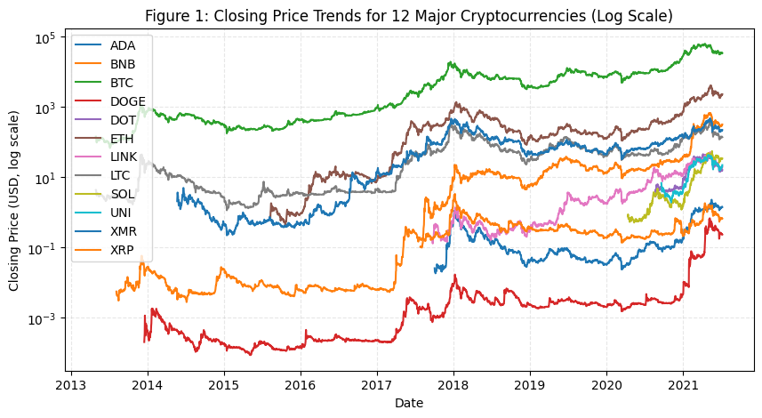

```python
# Figure 1: Closing Price Trends for 12 Major Cryptocurrencies (Log Scale)
plt.figure(figsize=(10, 5))
for coin, group in df.groupby('coin'):
    plt.plot(group['Date'], group['Close'], label=coin)
plt.yscale('log')
plt.title("Figure 1: Closing Price Trends for 12 Major Cryptocurrencies (Log Scale)")
plt.xlabel("Date")
plt.ylabel("Closing Price (USD, log scale)")
plt.legend()
plt.grid(alpha=0.3, which='both', linestyle='--')
plt.show()
```

**Explanation:**

This plot shows the long-term price evolution of 12 major cryptocurrencies on a logarithmic scale. Using a log scale makes it possible to compare assets with prices that span several orders of magnitude. We can see clear market cycles—periods of rapid appreciation followed by extended drawdowns.

Bitcoin remains the most stable and highest-valued asset, while other coins such as Ethereum, Binance Coin, and Solana exhibit significant growth and volatility. Dogecoin and some others show highly speculative and irregular spikes. These patterns highlight the non-linear and volatile nature of cryptocurrency markets, suggesting that models should incorporate time-dependent features (e.g., lags, volatility) rather than assuming simple linear trends.

##### Figure 2: Distribution of Daily Returns for 12 Major Cryptocurrencies (Log Y, Density)

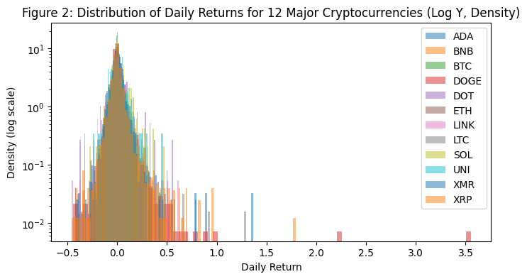

```python
# Figure 2: Distribution of Daily Returns for 12 Major Cryptocurrencies (Log Y, Density)
plt.figure(figsize=(8, 4))
for coin, group in df.groupby('coin'):
    returns = group['Close'].pct_change()
    plt.hist(returns, bins=80, alpha=0.5, label=coin, density=True)
plt.yscale('log')
plt.title("Figure 2: Distribution of Daily Returns for 12 Major Cryptocurrencies (Log Y, Density)")
plt.xlabel("Daily Return")
plt.ylabel("Density (log scale)")
plt.legend()
plt.show()
```

**Explanation:**

This figure shows the distribution of daily returns for the 12 selected cryptocurrencies on a log-scaled y-axis. Most returns cluster around zero, but the distributions have long tails, indicating that large price jumps (up or down) occur more frequently than in traditional financial markets. This highlights the high volatility of crypto assets and shows why short-term prediction is challenging—the data contain sudden, irregular movements that are difficult for simple models to capture.

##### Figure 3: Daily Trading Volume for 12 Major Cryptocurrencies (Log Scale)

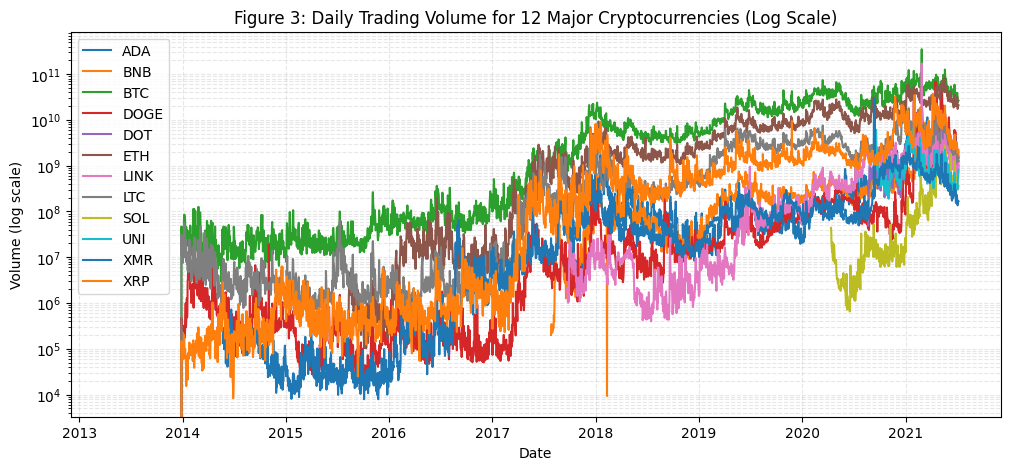

```python
# Figure 3: Daily Trading Volume for 12 Major Cryptocurrencies (Log Scale)
plt.figure(figsize=(12, 5))
for coin, group in df.groupby('coin'):
    plt.plot(group['Date'], group['Volume'], label=coin)
plt.yscale('log')
plt.title("Figure 3: Daily Trading Volume for 12 Major Cryptocurrencies (Log Scale)")
plt.xlabel("Date")
plt.ylabel("Volume (log scale)")
plt.legend()
plt.grid(alpha=0.3, which='both', linestyle='--')
plt.show()
```

##### Figure 4: Feature vs Target Relationship

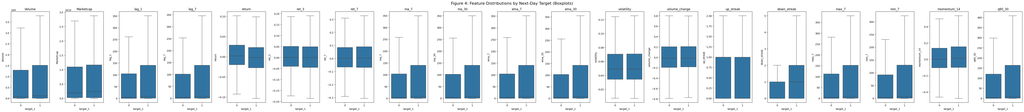

```python
# Figure 4: Feature Distributions by Next-Day Target (Tagret_1)
import seaborn as sns

# Automatically get all numeric features (excluding targets, Close, Date)
all_features = [col for col in feature_df.columns if col not in ['Date', 'Close', 'target', 'target_1', 'target_3', 'target_5', 'target_7']]

fig, axes = plt.subplots(nrows=1, ncols=len(all_features), figsize=(3*len(all_features), 6))
if len(all_features) == 1:
    axes = [axes]
for i, feature in enumerate(all_features):
    sns.boxplot(x='target_1', y=feature, data=feature_df, ax=axes[i], showfliers=False)
    axes[i].set_title(feature)
    axes[i].set_xlabel('target_1')
plt.tight_layout()
plt.suptitle('Figure 4: Feature Distributions by Next-Day Target (Boxplots)', y=1.03, fontsize=16)
plt.show()
```

**Explanation:**

This figure shows the distribution of each engineered feature grouped by the short-term target (target_1, i.e., next-day up/down) for the 12 selected cryptocurrencies. For each feature, the boxplot compares its value when the next day's price goes up (target=1) versus down (target=0).

Most features show only weak separation between up and down days, highlighting the challenging and noisy nature of short-term cryptocurrency prediction. The substantial overlap in feature distributions indicates that no single indicator is strongly predictive on its own. This suggests that combining multiple features and using robust, regularized models is necessary to capture meaningful patterns. Stablecoins are not included, as their lack of volatility would obscure these relationships.

##### Figure 5: Feature Correlation Heatmap

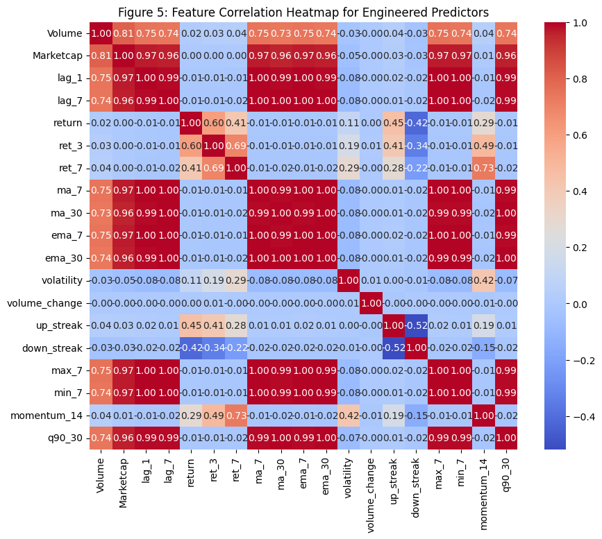

```python
# Figure 5: Feature Correlation Heatmap for Engineered Predictors

import seaborn as sns
plt.figure(figsize=(10, 8))
# Get all features (no target、Close、Date）
all_features = [col for col in feature_df.columns if col not in ['Date', 'Close', 'target', 'target_1', 'target_3', 'target_5', 'target_7']]
corr = feature_df[all_features].corr()

sns.heatmap(corr, annot=True, cmap='coolwarm', fmt='.2f', square=True)

plt.title('Figure 5: Feature Correlation Heatmap for Engineered Predictors')

plt.show()
```

**Explanation:**

The correlation heatmap shows that price-related features (lag_1, lag_7, ma_7, ma_30) are highly correlated with each other, confirming that they mainly represent the same underlying trend information. In contrast, return is almost uncorrelated with these trend features, indicating that it captures short-term momentum and provides an independent signal.

### 3. Models

#### 3.1 Model Selection and Training Data Preparation

The exploratory analysis suggests that daily price movements are difficult to separate using simple patterns—features for up and down days overlap heavily, and the short-term relationships in the data appear weak. Because of this, the goal is not to find a perfect classifier, but to compare how different types of models handle noisy financial data.

Logistic Regression is used as a baseline because it provides a clear view of how well a simple linear model performs. Random Forest and XGBoost are then included as more flexible alternatives that can capture nonlinear patterns and interactions between features. These tree-based models are well suited for datasets where signals may be subtle and not linearly separable.

```python
# Train-test split
split_idx = int(len(feature_df) * 0.8)
X = feature_df.select_dtypes(include=[np.number]).drop(columns=['target_1', 'target_3', 'target_5', 'target_7'], errors='ignore')
X_train, X_test = X.iloc[:split_idx], X.iloc[split_idx:]
y1_train, y1_test = feature_df['target_1'].iloc[:split_idx], feature_df['target_1'].iloc[split_idx:]
y3_train, y3_test = feature_df['target_3'].iloc[:split_idx], feature_df['target_3'].iloc[split_idx:]
y5_train, y5_test = feature_df['target_5'].iloc[:split_idx], feature_df['target_5'].iloc[split_idx:]
y7_train, y7_test = feature_df['target_7'].iloc[:split_idx], feature_df['target_7'].iloc[split_idx:]
print(f"Train set: {X_train.shape[0]} samples")
print(f"Test set: {X_test.shape[0]} samples")
```

```
Train set: 16603 samples
Test set: 4151 samples
```

#### 3.2 Model Training and Evaluation:

This section introduces the training and evaluation process for three types of models, each tested across multiple forecast horizons (1, 3, 5, 7 days). The structure is as follows:

1. **Logistic Regression**: Serves as a linear baseline model. Training and evaluation are performed for each horizon, with accuracy summarized in a table.
2. **Random Forest**: Represents tree-based ensemble models. Each horizon is modeled independently, with confusion matrices and accuracies shown, followed by a summary table.
3. **XGBoost (Extreme Gradient Boosting)**: A powerful boosting tree model, following a similar structure to Random Forest, with emphasis on its ability to capture nonlinearities and noise. Each model section includes:
- A brief method description
- Training and evaluation code for each forecast horizon
- A summary table of results for easy comparison

##### 3.2.1 Logistic Regression

Logistic Regression serves as a baseline model for predicting next-day price movement in the cryptocurrency market. As a simple linear classifier, it provides a reference point for evaluating the added value of more complex models. The model is trained on the training set and evaluated on the test set using accuracy. This approach helps to quantify the inherent predictability in the data and highlights the limitations of linear methods in capturing the complex, nonlinear patterns often present in financial time series.

```python
# Multi-horizon Logistic Regression
from sklearn.linear_model import LogisticRegression
from sklearn.metrics import accuracy_score, confusion_matrix, classification_report
import warnings
warnings.filterwarnings('ignore')

horizons = [1, 3, 5, 7]
results_logreg = []

for h in horizons:
    target_col = f'target_{h}'
    y = feature_df[target_col]
    split_idx = int(len(feature_df) * 0.8)
    X_train, X_test = X.iloc[:split_idx], X.iloc[split_idx:]
    y_train, y_test = y.iloc[:split_idx], y.iloc[split_idx:]

    logreg = LogisticRegression(max_iter=1000, random_state=42)
    logreg.fit(X_train, y_train)
    y_pred_logreg = logreg.predict(X_test)
    acc_logreg = accuracy_score(y_test, y_pred_logreg)
    print(f"Logistic Regression Accuracy (horizon {h}): {acc_logreg:.4f}")
    print("Confusion Matrix:\n", confusion_matrix(y_test, y_pred_logreg))
    results_logreg.append({'horizon': h, 'model': 'LogReg', 'acc': acc_logreg})

# Results summary for Logistic Regression
import pandas as pd
results_df_logreg = pd.DataFrame(results_logreg)
results_df_logreg = results_df_logreg.drop_duplicates(subset=['horizon', 'model'], keep='last')
try:
    display(results_df_logreg.pivot(index='horizon', columns='model', values='acc'))
except ValueError:
    print('Warning: Duplicate entries in results, showing raw table instead.')
    display(results_df_logreg)
```

```
Logistic Regression Accuracy (horizon 1): 0.5312
Confusion Matrix:
 [[1237  912]
 [1034  968]]
Logistic Regression Accuracy (horizon 3): 0.5317
Confusion Matrix:
 [[1423  758]
 [1186  784]]
Logistic Regression Accuracy (horizon 5): 0.5584
Confusion Matrix:
 [[1433  774]
 [1059  885]]
Logistic Regression Accuracy (horizon 7): 0.5560
Confusion Matrix:
 [[1472  701]
 [1142  836]]
```

| model horizon | LogReg |
| --- | --- |
| 1 | 0.531197 |
| 3 | 0.531679 |
| 5 | 0.558420 |
| 7 | 0.556011 |

##### 3.2.2 Random Forest

Random Forest is an ensemble learning method that builds multiple decision trees and combines their predictions to improve accuracy and robustness. It is well-suited for capturing nonlinear relationships and complex interactions among features, which are common in financial time series data. In this project, Random Forest is trained to predict price movement, and its performance is evaluated using accuracy. This model helps assess whether more flexible, nonlinear approaches can outperform simple linear classifiers in the context of cryptocurrency price prediction.

```python
# Random Forest: Horizon 1
from sklearn.ensemble import RandomForestClassifier
from sklearn.metrics import accuracy_score, confusion_matrix, classification_report

rf1 = RandomForestClassifier(n_estimators=260, max_depth=6, min_samples_leaf=1, random_state=42)
rf1.fit(X_train, y1_train)
y_pred_rf1 = rf1.predict(X_test)
acc_rf1 = accuracy_score(y1_test, y_pred_rf1)
print(f"Random Forest (horizon 1) Accuracy: {acc_rf1:.4f}")
print("Confusion Matrix:\n", confusion_matrix(y1_test, y_pred_rf1))
```

```
Random Forest (horizon 1) Accuracy: 0.5616
Confusion Matrix:
 [[1497  652]
 [1168  834]]
```

```python
# Random Forest: Horizon 3
rf3 = RandomForestClassifier(n_estimators=270, max_depth=6, min_samples_leaf=1, random_state=42)
rf3.fit(X_train, y3_train)
y_pred_rf3 = rf3.predict(X_test)
acc_rf3 = accuracy_score(y3_test, y_pred_rf3)
print(f"Random Forest (horizon 3) Accuracy: {acc_rf3:.4f}")
print("Confusion Matrix:\n", confusion_matrix(y3_test, y_pred_rf3))
```

```
Random Forest (horizon 3) Accuracy: 0.5437
Confusion Matrix:
 [[1210  971]
 [ 923 1047]]
```

```python
# Random Forest: Horizon 5
rf5 = RandomForestClassifier(n_estimators=250, max_depth=6, min_samples_leaf=1, random_state=42) # 你可以手动调参数
rf5 .fit(X_train, y5_train)
y_pred_rf5 = rf5 .predict(X_test)
acc_rf5 = accuracy_score(y5_test, y_pred_rf5)
print(f"Random Forest (horizon 5) Accuracy: {acc_rf5:.4f}")
print("Confusion Matrix:\n", confusion_matrix(y5_test, y_pred_rf5))
```

```
Random Forest (horizon 5) Accuracy: 0.5283
Confusion Matrix:
 [[1118 1089]
 [ 869 1075]]
```

```python
# Random Forest: Horizon 7
rf7 = RandomForestClassifier(n_estimators=200, max_depth=6, min_samples_leaf=1, random_state=42) # 你可以手动调参数
rf7.fit(X_train, y7_train)
y_pred_rf7 = rf7.predict(X_test)
acc_rf7 = accuracy_score(y7_test, y_pred_rf7)
print(f"Random Forest (horizon 7) Accuracy: {acc_rf7:.4f}")
print("Confusion Matrix:\n", confusion_matrix(y7_test, y_pred_rf7))
```

```
Random Forest (horizon 7) Accuracy: 0.5298
Confusion Matrix:
 [[ 985 1188]
 [ 764 1214]]
```

```python
# Summary table for Random Forest models across all horizons
results_rf = []
results_rf.append({'horizon': 1, 'model': 'RandomForest', 'acc': acc_rf1})
results_rf.append({'horizon': 3, 'model': 'RandomForest', 'acc': acc_rf3})
results_rf.append({'horizon': 5, 'model': 'RandomForest', 'acc': acc_rf5})
results_rf.append({'horizon': 7, 'model': 'RandomForest', 'acc': acc_rf7})

results_df_rf = pd.DataFrame(results_rf)
display(results_df_rf)
```

|  | horizon | model | acc |
| --- | --- | --- | --- |
| 0 | 1 | RandomForest | 0.561551 |
| 1 | 3 | RandomForest | 0.543724 |
| 2 | 5 | RandomForest | 0.528306 |
| 3 | 7 | RandomForest | 0.529752 |

##### 3.2.3 XGBoost (Extreme Gradient Boosting)

XGBoost is a powerful gradient boosting algorithm that builds an ensemble of decision trees in a sequential manner, optimizing for predictive accuracy. It is particularly effective at modeling complex, nonlinear relationships and handling noisy data, which are common in financial time series. XGBoost is used to predict price movement and its performance is evaluated using accuracy. This model provides insight into whether advanced boosting techniques can further improve prediction over both linear and standard ensemble methods in the context of cryptocurrency markets.

```python
# XGBoost: Four horizons (separate cells for easy tuning)
from xgboost import XGBClassifier
from sklearn.metrics import accuracy_score, confusion_matrix, classification_report

# Horizon 1
y = feature_df['target_1']
xgb1 = XGBClassifier(n_estimators=100, max_depth=3, learning_rate=0.06, eval_metric='logloss', random_state=42, use_label_encoder=False)
xgb1.fit(X_train, y1_train)
y_pred_xgb1 = xgb1.predict(X_test)
acc_xgb1 = accuracy_score(y1_test, y_pred_xgb1)
print(f"XGBoost (horizon 1) Accuracy: {acc_xgb1:.4f}")
print("Confusion Matrix:\n", confusion_matrix(y_test, y_pred_xgb1))
```

```
XGBoost (horizon 1) Accuracy: 0.5606
Confusion Matrix:
 [[1346  827]
 [1077  901]]
```

```python
# Horizon 3
y = feature_df['target_3']
xgb3 = XGBClassifier(n_estimators=148, max_depth=4, learning_rate=0.03, eval_metric='logloss', random_state=42, use_label_encoder=False)
xgb3.fit(X_train, y3_train)
y_pred_xgb3 = xgb3.predict(X_test)
acc_xgb3 = accuracy_score(y3_test, y_pred_xgb3)
print(f"XGBoost (horizon 3) Accuracy: {acc_xgb3:.4f}")
print("Confusion Matrix:\n", confusion_matrix(y_test, y_pred_xgb3))
```

```
XGBoost (horizon 3) Accuracy: 0.5526
Confusion Matrix:
 [[1254  919]
 [ 906 1072]]
```

```python
# Horizon 5
y = feature_df['target_5']
xgb5 = XGBClassifier(n_estimators=265, max_depth=5, learning_rate=0.02, eval_metric='logloss', random_state=42, use_label_encoder=False)
xgb5.fit(X_train, y5_train)
y_pred_xgb5 = xgb5.predict(X_test)
acc_xgb5 = accuracy_score(y5_test, y_pred_xgb5)
print(f"XGBoost (horizon 5) Accuracy: {acc_xgb5:.4f}")
print("Confusion Matrix:\n", confusion_matrix(y_test, y_pred_xgb5))
```

```
XGBoost (horizon 5) Accuracy: 0.5338
Confusion Matrix:
 [[1067 1106]
 [ 811 1167]]
```

```python
# Horizon 7
y = feature_df['target_7']
xgb7 = XGBClassifier(n_estimators=380, max_depth=4, learning_rate=0.05, eval_metric='logloss', random_state=42, use_label_encoder=False)
xgb7.fit(X_train, y7_train)
y_pred_xgb7 = xgb7.predict(X_test)
acc_xgb7 = accuracy_score(y7_test, y_pred_xgb7)
print(f"XGBoost (horizon 7) Accuracy: {acc_xgb7:.4f}")
print("Confusion Matrix:\n", confusion_matrix(y7_test, y_pred_xgb7))
```

```
XGBoost (horizon 7) Accuracy: 0.5240
Confusion Matrix:
 [[ 858 1315]
 [ 661 1317]]
```

```python
# Summary table for XGBoost models across all horizons
results_xg = []
results_xg.append({'horizon': 1, 'model': 'XGBoost', 'acc': acc_xgb1})
results_xg.append({'horizon': 3, 'model': 'XGBoost', 'acc': acc_xgb3})
results_xg.append({'horizon': 5, 'model': 'XGBoost', 'acc': acc_xgb5})
results_xg.append({'horizon': 7, 'model': 'XGBoost', 'acc': acc_xgb7})
results_df_xg = pd.DataFrame(results_xg)
display(results_df_xg)
```

|  | horizon | model | acc |
| --- | --- | --- | --- |
| 0 | 1 | XGBoost | 0.560588 |
| 1 | 3 | XGBoost | 0.552638 |
| 2 | 5 | XGBoost | 0.533847 |
| 3 | 7 | XGBoost | 0.523970 |

### 4. Results

#### 4.1 Overall Model Performance

```
Combined Model Performance Across All Horizons:
```

| model horizon | LogReg | RandomForest | XGBoost |
| --- | --- | --- | --- |
| 1 | 0.531197 | 0.561551 | 0.560588 |
| 3 | 0.531679 | 0.543724 | 0.552638 |
| 5 | 0.558420 | 0.528306 | 0.533847 |
| 7 | 0.556011 | 0.529752 | 0.523970 |

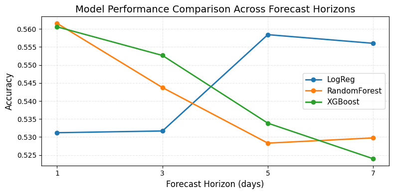

```python
# Combined results table for all three models across all horizons
combined_results = pd.concat([results_df_logreg, results_df_rf, results_df_xg], ignore_index=True)

# Pivot table for better visualization
combined_pivot = combined_results.pivot(index='horizon', columns='model', values='acc')

# Display the combined table
print("Combined Model Performance Across All Horizons:")
display(combined_pivot)

# Visualization
fig, ax = plt.subplots(figsize=(8, 4))
for model in combined_pivot.columns:
    ax.plot(combined_pivot.index, combined_pivot[model], marker='o', label=model, linewidth=2)

ax.set_xlabel('Forecast Horizon (days)', fontsize=12)
ax.set_ylabel('Accuracy', fontsize=12)
ax.set_title('Model Performance Comparison Across Forecast Horizons', fontsize=14)
ax.legend(fontsize=11)
ax.grid(alpha=0.3, linestyle='--')
ax.set_xticks([1, 3, 5, 7])
plt.tight_layout()
plt.show()
```

**Explanation**:

All three models (Logistic Regression, Random Forest, XGBoost) were evaluated on four forecast horizons (1, 3, 5, and 7 days). The tables below summarize the test accuracy for each model. Overall performance ranges from 0.52 to 0.56, which is expected given the noisy and volatile nature of crypto markets.

#### 4.3 Feature Importance of Horizon 1 (Random Forest & XGBoost)

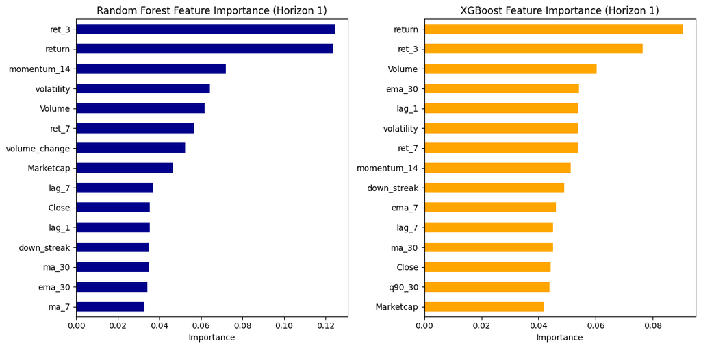

```python
# Feature Importance Plots for Random Forest and XGBoost (Horizon 1 Example)
importances_rf = rf1.feature_importances_
importances_xgb = xgb1.feature_importances_
feature_names = X_train.columns

fig, axes = plt.subplots(1, 2, figsize=(12, 6))

# Random Forest Feature Importance (Left)
rf_imp = pd.Series(importances_rf, index=feature_names).sort_values(ascending=False)
rf_imp.head(15).iloc[::-1].plot(kind='barh', color='darkblue', ax=axes[0])
axes[0].set_title('Random Forest Feature Importance (Horizon 1)')
axes[0].set_xlabel('Importance')

# XGBoost Feature Importance (Right)
xgb_imp = pd.Series(importances_xgb, index=feature_names).sort_values(ascending=False)
xgb_imp.head(15).iloc[::-1].plot(kind='barh', color='orange', ax=axes[1])
axes[1].set_title('XGBoost Feature Importance (Horizon 1)')
axes[1].set_xlabel('Importance')

plt.tight_layout()
plt.show()
```

**Explanation (Random Forest):**

For the 1-day horizon, Random Forest assigns the highest importance to very short-term price changes, particularly the 3-day return (ret_3) and the most recent daily return. Volume-related features also appear near the top, suggesting that trading activity carries useful information for predicting next-day direction.

Longer-term features, such as 7-day returns, moving averages, and EMA values— contribute less. This pattern indicates that most of the usable predictive signal in crypto markets comes from the most recent price movements rather than from slower trend indicators.

**Explanation (XGBoost):**

Compared with Random Forest, XGBoost places slightly more weight on individual lag features (e.g., lag_1) and longer-horizon moving averages. However, the overall ranking confirms the same conclusion: next-day price direction is influenced primarily by very recent market behavior, while longer-term technical indicators provide relatively weak incremental signal.

##### 4.3.3 Summary

Across both models, short-term returns consistently dominate feature importance, highlighting the limited but detectable short-horizon momentum effects in crypto markets.

### 5. Discussion

#### 5.1 Predictability in Crypto Markets

The results show that cryptocurrency price movements contain only weak short-term predictive signals, with models achieving around 53–56% accuracy on the 1-day horizon. This is broadly consistent with prior research showing that crypto markets are extremely volatile and dominated by noise, which limits predictability (Chu et al., 2017).

#### 5.2 Model Comparison

Logistic Regression, Random Forest, and XGBoost perform similarly across all horizons, with only small differences in accuracy. The weak improvements from nonlinear models indicate that the underlying predictive signal is limited and largely short-term. In other words, even flexible models like RF and XGB do not appear to uncover much additional structure beyond what a simple linear model can already capture.

#### 5.3 Feature Importance Insights

Feature importance results from both tree-based models reveal that:

- Short-term returns (e.g., daily return, 3-day return) carry the most predictive information
- Volume and volatility contribute moderately

Longer-term moving averages and slow trend indicators have little impact

This suggests that crypto markets exhibit very short-lived momentum, which quickly decays.

#### 5.4 Interpretation of Horizon Decay

- Market sentiment, which can shift abruptly due to social media, investor mood, or crowd behavior
- Speculative trading behavior, where short-term momentum and fear-of-missing-out (FOMO) dynamics create irregular and unstable patterns
- External shocks, such as regulatory announcements, macroeconomic news, exchange outages, or forced liquidations

### 7. Reference

1. Rajkumar, S. (2018). *Cryptocurrency Historical Prices*. Kaggle. https://www.kaggle.com/datasets/sudalairajkumar/cryptocurrencypricehistory
2. Urquhart, A. (2016). The inefficiency of Bitcoin. *Economics Letters, 148*, 80–82.
3. Chu, J., Chan, S., Nadarajah, S., & Osterrieder, J. (2017). GARCH modelling of cryptocurrencies. *Journal of Risk and Financial Management, 10*(4), 17.
4. Corbet, S., Lucey, B., Urquhart, A., & Yarovaya, L. (2019). Cryptocurrencies as a financial asset: A systematic analysis. *International Review of Financial Analysis, 62*, 182–199.